# Business Understanding

Airbnb is an American vacation rental online marketplace company based in United States. They hosts a marketplace, accessible to consumers on its website/app.

In this project I'm going to Analyze Airbnb-Istanbul Dataset. Istanbul is the biggest city in Turkey with 16 Million people. Also Turkeys biggest companies are also located in Istanbul. On the other hand Istanbul is represent the harmony of the history and today. There is iconic places like Hagia Sophia, Blue Mosque, Taksim Square and so on. Istanbul is connecting Asia and Europa continents each other with 3 Bridge and 1 tunnel also. So People are wondering the Istanbul and they would like to travel. Airbnb is providing houses in Istanbul to who would like to stay Istanbul in website/app.

I'm going to analyze the house prices in Istanbul. Here is my questions to find the answers:

#### Question 1: How many hosts have more than 1 listings?

#### Question 2: Is Continent related to prices?

#### Question 3: My House is in European side of Istanbul. Is it good to listing my house in Airbnb?

#### Question 4: Can I predict the listing prices?

```python
#import necessary libraries
import numpy as np
import pandas as pd

import matplotlib.pyplot as plt
import seaborn as sns

from datetime import datetime

from sklearn.linear_model import LinearRegression
from sklearn.model_selection import train_test_split, GridSearchCV
from sklearn.metrics import r2_score, mean_squared_error, make_scorer
from sklearn.ensemble import RandomForestRegressor
from sklearn.preprocessing import StandardScaler


import xgboost as xg
```

```python
import warnings
warnings.filterwarnings("ignore", category=FutureWarning)
```

```python
#Setting pandas view options
pd.options.display.max_rows = 999
pd.options.display.max_columns = 999
```

# Data Understanding

## Gather

```python
df_listing = pd.read_csv('listings.csv.gz')
```

```python
df_listing.head(5)
```

|  | id | listing_url | scrape_id | last_scraped | name | description | neighborhood_overview | picture_url | host_id | host_url | host_name | host_since | host_location | host_about | host_response_time | host_response_rate | host_acceptance_rate | host_is_superhost | host_thumbnail_url | host_picture_url | host_neighbourhood | host_listings_count | host_total_listings_count | host_verifications | host_has_profile_pic | host_identity_verified | neighbourhood | neighbourhood_cleansed | neighbourhood_group_cleansed | … |
| --- | --- | --- | --- | --- | --- | --- | --- | --- | --- | --- | --- | --- | --- | --- | --- | --- | --- | --- | --- | --- | --- | --- | --- | --- | --- | --- | --- | --- | --- | --- |
| 0 | 20815 | https://www.airbnb.com/rooms/20815 | 20201027172200 | 2020-10-27 | The Bosphorus from The Comfy Hill | Watch The Bosphorus from The Comfy Hill.<br />... | The lovely neighborhood, Arnavutkoy, is locate... | https://a0.muscache.com/pictures/94805791/481d... | 78838 | https://www.airbnb.com/users/show/78838 | Gülder | 2010-02-08 | Ankara, Ankara, Turkey | Başar Family\r\n\r\nGülder (mother): Owner of ... | NaN | NaN | NaN | f | https://a0.muscache.com/im/users/78838/profile... | https://a0.muscache.com/im/users/78838/profile... | Beşiktaş | 2.0 | 2.0 | ['email', 'phone', 'facebook', 'reviews', 'wor... | t | f | Istanbul, Turkey | Besiktas | NaN | … |
| 1 | 27271 | https://www.airbnb.com/rooms/27271 | 20201027172200 | 2020-10-28 | Lovely apartment in perfect location | This is a nicely decorated apartment in an an... | Cihangir is one of Istanbul's cosmopolitan sub... | https://a0.muscache.com/pictures/2f9cfc85-8370... | 117026 | https://www.airbnb.com/users/show/117026 | Mutlu | 2010-05-02 | Istanbul, Istanbul, Turkey | I am a tourist guide and diving instructor. I... | NaN | NaN | 0% | f | https://a0.muscache.com/im/pictures/user/44954... | https://a0.muscache.com/im/pictures/user/44954... | Cihangir | 1.0 | 1.0 | ['email', 'phone', 'facebook', 'reviews', 'jum... | t | t | Istanbul Province, Turkey | Beyoglu | NaN | … |
| 2 | 28318 | https://www.airbnb.com/rooms/28318 | 20201027172200 | 2020-10-28 | Cosy home overlooking Bosphorus | <b>The space</b><br />Easy access to both brid... | Close to Bosphorus University<br />Close to Be... | https://a0.muscache.com/pictures/76617600/0ab5... | 121721 | https://www.airbnb.com/users/show/121721 | Aydin | 2010-05-10 | Istanbul, Istanbul, Turkey | Hardworking guy with many interests. Curious a... | a few days or more | 0% | NaN | f | https://a0.muscache.com/im/users/121721/profil... | https://a0.muscache.com/im/users/121721/profil... | NaN | 1.0 | 1.0 | ['email', 'phone', 'reviews', 'jumio', 'govern... | t | t | İstanbul, Turkey | Sariyer | NaN | … |
| 3 | 29241 | https://www.airbnb.com/rooms/29241 | 20201027172200 | 2020-10-28 | ↪ Istanbul, Your second house | <b>The space</b><br />There are many interesti... | NaN | https://a0.muscache.com/pictures/12385994/b9ba... | 125742 | https://www.airbnb.com/users/show/125742 | Şevki | 2010-05-16 | Istanbul, Istanbul, Turkey | I am 34 years old live with my mother.I like t... | NaN | NaN | NaN | f | https://a0.muscache.com/im/users/125742/profil... | https://a0.muscache.com/im/users/125742/profil... | Beyoglu | 1.0 | 1.0 | ['email', 'phone', 'facebook'] | t | f | NaN | Beyoglu | NaN | … |
| 4 | 30697 | https://www.airbnb.com/rooms/30697 | 20201027172200 | 2020-10-27 | nice home in popular area | <b>The space</b><br />I can ensure you that th... | NaN | https://a0.muscache.com/pictures/6392807/b6f01... | 132137 | https://www.airbnb.com/users/show/132137 | Nan | 2010-05-25 | Istanbul, Istanbul, Turkey | I'm a fashion photographer, retouch artist and... | NaN | NaN | NaN | f | https://a0.muscache.com/im/pictures/user/936b1... | https://a0.muscache.com/im/pictures/user/936b1... | Taksim | 1.0 | 1.0 | ['phone', 'reviews', 'jumio', 'offline_governm... | t | t | NaN | Beyoglu | NaN | … |

```python
df_listing.describe().round().transpose()
```

|  | count | mean | std | min | 25% | 50% | 75% | max |
| --- | --- | --- | --- | --- | --- | --- | --- | --- |
| id | 22328.0 | 3.155600e+07 | 13586204.0 | 2.081500e+04 | 2.450524e+07 | 3.631336e+07 | 4.228272e+07 | 4.607936e+07 |
| scrape_id | 22328.0 | 2.020103e+13 | 5.0 | 2.020103e+13 | 2.020103e+13 | 2.020103e+13 | 2.020103e+13 | 2.020103e+13 |
| host_id | 22328.0 | 1.639632e+08 | 123838697.0 | 1.176800e+04 | 3.651885e+07 | 1.712101e+08 | 2.732590e+08 | 3.734541e+08 |
| host_listings_count | 22318.0 | 1.400000e+01 | 91.0 | 0.000000e+00 | 1.000000e+00 | 2.000000e+00 | 5.000000e+00 | 1.005000e+03 |
| host_total_listings_count | 22318.0 | 1.400000e+01 | 91.0 | 0.000000e+00 | 1.000000e+00 | 2.000000e+00 | 5.000000e+00 | 1.005000e+03 |
| neighbourhood_group_cleansed | 0.0 | NaN | NaN | NaN | NaN | NaN | NaN | NaN |
| latitude | 22328.0 | 4.100000e+01 | 0.0 | 4.100000e+01 | 4.100000e+01 | 4.100000e+01 | 4.100000e+01 | 4.100000e+01 |
| longitude | 22328.0 | 2.900000e+01 | 0.0 | 2.800000e+01 | 2.900000e+01 | 2.900000e+01 | 2.900000e+01 | 3.000000e+01 |
| accommodates | 22328.0 | 3.000000e+00 | 2.0 | 0.000000e+00 | 2.000000e+00 | 2.000000e+00 | 4.000000e+00 | 1.600000e+01 |
| bathrooms | 0.0 | NaN | NaN | NaN | NaN | NaN | NaN | NaN |
| bedrooms | 20456.0 | 2.000000e+00 | 2.0 | 1.000000e+00 | 1.000000e+00 | 1.000000e+00 | 2.000000e+00 | 5.000000e+01 |
| beds | 21635.0 | 2.000000e+00 | 3.0 | 0.000000e+00 | 1.000000e+00 | 2.000000e+00 | 2.000000e+00 | 1.950000e+02 |
| minimum_nights | 22328.0 | 5.000000e+00 | 21.0 | 1.000000e+00 | 1.000000e+00 | 1.000000e+00 | 3.000000e+00 | 7.300000e+02 |
| maximum_nights | 22328.0 | 9.743600e+04 | 14371744.0 | 1.000000e+00 | 9.000000e+01 | 1.125000e+03 | 1.125000e+03 | 2.147484e+09 |
| minimum_minimum_nights | 22328.0 | 5.000000e+00 | 25.0 | 1.000000e+00 | 1.000000e+00 | 1.000000e+00 | 3.000000e+00 | 7.300000e+02 |
| maximum_minimum_nights | 22328.0 | 9.000000e+00 | 60.0 | 1.000000e+00 | 1.000000e+00 | 1.000000e+00 | 3.000000e+00 | 7.300000e+02 |
| minimum_maximum_nights | 22328.0 | 1.376000e+03 | 67326.0 | 1.000000e+00 | 3.650000e+02 | 1.125000e+03 | 1.125000e+03 | 1.000000e+07 |
| maximum_maximum_nights | 22328.0 | 1.379000e+03 | 67326.0 | 1.000000e+00 | 3.650000e+02 | 1.125000e+03 | 1.125000e+03 | 1.000000e+07 |
| minimum_nights_avg_ntm | 22328.0 | 6.000000e+00 | 37.0 | 1.000000e+00 | 1.000000e+00 | 1.000000e+00 | 3.000000e+00 | 7.300000e+02 |
| maximum_nights_avg_ntm | 22328.0 | 1.377000e+03 | 67326.0 | 1.000000e+00 | 3.650000e+02 | 1.125000e+03 | 1.125000e+03 | 1.000000e+07 |
| calendar_updated | 0.0 | NaN | NaN | NaN | NaN | NaN | NaN | NaN |
| availability_30 | 22328.0 | 2.400000e+01 | 10.0 | 0.000000e+00 | 2.300000e+01 | 2.900000e+01 | 3.000000e+01 | 3.000000e+01 |
| availability_60 | 22328.0 | 5.100000e+01 | 17.0 | 0.000000e+00 | 5.300000e+01 | 5.900000e+01 | 6.000000e+01 | 6.000000e+01 |
| availability_90 | 22328.0 | 7.900000e+01 | 22.0 | 0.000000e+00 | 8.300000e+01 | 8.900000e+01 | 9.000000e+01 | 9.000000e+01 |
| availability_365 | 22328.0 | 2.730000e+02 | 117.0 | 0.000000e+00 | 1.790000e+02 | 3.570000e+02 | 3.650000e+02 | 3.650000e+02 |
| number_of_reviews | 22328.0 | 8.000000e+00 | 24.0 | 0.000000e+00 | 0.000000e+00 | 0.000000e+00 | 4.000000e+00 | 3.530000e+02 |
| number_of_reviews_ltm | 22328.0 | 2.000000e+00 | 6.0 | 0.000000e+00 | 0.000000e+00 | 0.000000e+00 | 1.000000e+00 | 1.550000e+02 |
| number_of_reviews_l30d | 22328.0 | 0.000000e+00 | 1.0 | 0.000000e+00 | 0.000000e+00 | 0.000000e+00 | 0.000000e+00 | 2.600000e+01 |
| review_scores_rating | 10251.0 | 9.100000e+01 | 15.0 | 2.000000e+01 | 9.000000e+01 | 9.600000e+01 | 1.000000e+02 | 1.000000e+02 |
| review_scores_accuracy | 10242.0 | 9.000000e+00 | 2.0 | 2.000000e+00 | 9.000000e+00 | 1.000000e+01 | 1.000000e+01 | 1.000000e+01 |
| review_scores_cleanliness | 10245.0 | 9.000000e+00 | 2.0 | 2.000000e+00 | 9.000000e+00 | 1.000000e+01 | 1.000000e+01 | 1.000000e+01 |
| review_scores_checkin | 10242.0 | 1.000000e+01 | 1.0 | 2.000000e+00 | 1.000000e+01 | 1.000000e+01 | 1.000000e+01 | 1.000000e+01 |
| review_scores_communication | 10246.0 | 1.000000e+01 | 1.0 | 2.000000e+00 | 1.000000e+01 | 1.000000e+01 | 1.000000e+01 | 1.000000e+01 |
| review_scores_location | 10243.0 | 9.000000e+00 | 1.0 | 2.000000e+00 | 9.000000e+00 | 1.000000e+01 | 1.000000e+01 | 1.000000e+01 |
| review_scores_value | 10241.0 | 9.000000e+00 | 1.0 | 2.000000e+00 | 9.000000e+00 | 1.000000e+01 | 1.000000e+01 | 1.000000e+01 |
| license | 0.0 | NaN | NaN | NaN | NaN | NaN | NaN | NaN |
| calculated_host_listings_count | 22328.0 | 7.000000e+00 | 20.0 | 1.000000e+00 | 1.000000e+00 | 2.000000e+00 | 6.000000e+00 | 1.810000e+02 |
| calculated_host_listings_count_entire_homes | 22328.0 | 4.000000e+00 | 12.0 | 0.000000e+00 | 0.000000e+00 | 1.000000e+00 | 3.000000e+00 | 1.380000e+02 |
| calculated_host_listings_count_private_rooms | 22328.0 | 3.000000e+00 | 16.0 | 0.000000e+00 | 0.000000e+00 | 1.000000e+00 | 1.000000e+00 | 1.800000e+02 |
| calculated_host_listings_count_shared_rooms | 22328.0 | 0.000000e+00 | 1.0 | 0.000000e+00 | 0.000000e+00 | 0.000000e+00 | 0.000000e+00 | 1.800000e+01 |
| reviews_per_month | 10729.0 | 1.000000e+00 | 1.0 | 0.000000e+00 | 0.000000e+00 | 0.000000e+00 | 1.000000e+00 | 1.000000e+01 |

```python
df_listing.shape
```

```
(22328, 74)
```

```python
df_listing.describe(include = 'O').transpose()
```

|  | count | unique | top | freq |
| --- | --- | --- | --- | --- |
| listing_url | 22328 | 22328 | https://www.airbnb.com/rooms/35577002 | 1 |
| last_scraped | 22328 | 2 | 2020-10-27 | 15291 |
| name | 22294 | 21353 | İstanbul Birden fazla bölümden oluşan bina | 22 |
| description | 19445 | 17247 | Place is perfectly located in the heart of Ist... | 31 |
| neighborhood_overview | 9865 | 7598 | This furnished apartment is located in Maslak.... | 76 |
| picture_url | 22328 | 21365 | https://a0.muscache.com/pictures/a55511b9-55e5... | 20 |
| host_url | 22328 | 12651 | https://www.airbnb.com/users/show/45788344 | 181 |
| host_name | 22318 | 4452 | Mehmet | 398 |
| host_since | 22318 | 3115 | 2015-10-05 | 190 |
| host_location | 22249 | 688 | TR | 5367 |
| host_about | 10710 | 5174 | II was born in 1978 in Izmir. After I have gra... | 181 |
| host_response_time | 15609 | 4 | within an hour | 9481 |
| host_response_rate | 15609 | 69 | 100% | 9226 |
| host_acceptance_rate | 14231 | 79 | 100% | 6944 |
| host_is_superhost | 22318 | 2 | f | 19499 |
| host_thumbnail_url | 22318 | 12551 | https://a0.muscache.com/im/pictures/user/0ea3c... | 181 |
| host_picture_url | 22318 | 12551 | https://a0.muscache.com/im/pictures/user/0ea3c... | 181 |
| host_neighbourhood | 7619 | 52 | Taksim | 1713 |
| host_verifications | 22328 | 266 | ['email', 'phone'] | 5485 |
| host_has_profile_pic | 22318 | 2 | t | 22194 |
| host_identity_verified | 22318 | 2 | t | 13034 |
| neighbourhood | 9865 | 569 | Beyoğlu, İstanbul, Turkey | 2185 |
| neighbourhood_cleansed | 22328 | 39 | Beyoglu | 6104 |
| property_type | 22328 | 96 | Entire apartment | 7724 |
| room_type | 22328 | 4 | Entire home/apt | 11240 |
| bathrooms_text | 22233 | 61 | 1 bath | 11437 |
| amenities | 22328 | 18373 | [] | 230 |
| price | 22328 | 1509 | $80.00 | 1004 |
| has_availability | 22328 | 1 | t | 22328 |
| calendar_last_scraped | 22328 | 2 | 2020-10-27 | 15291 |
| first_review | 10729 | 2232 | 2020-01-01 | 56 |
| last_review | 10729 | 1418 | 2020-10-25 | 183 |
| instant_bookable | 22328 | 2 | t | 13791 |

### First Look

We have 74 Columns related to hosts,reviews,listings and Price

- 22328 Listings
- We have completely null and 0 variance variables which is going to be dropped
- latitude - longtitude is useless
- I will convert the t,f variables to 1,0
- Price is the string first job i'm going to fix it to number
- Some variables have list with string format i'm going to create dummy attributes from them
- Change the string format but actually numeric variables to numeric

## Data Preparation

```python
#First we need to convert string with $xx.xx format to numeric
df_listing['price'] = df_listing['price'].apply(lambda x: float(x[1:-3].replace(',','')))
```

```python
#check nulls

df_listing.isna().mean().sort_values(ascending = False)
```

```
bathrooms                                       1.000000
calendar_updated                                1.000000
neighbourhood_group_cleansed                    1.000000
license                                         1.000000
host_neighbourhood                              0.658769
neighborhood_overview                           0.558178
neighbourhood                                   0.558178
review_scores_value                             0.541338
review_scores_accuracy                          0.541293
review_scores_checkin                           0.541293
review_scores_location                          0.541249
review_scores_cleanliness                       0.541159
review_scores_communication                     0.541114
review_scores_rating                            0.540890
host_about                                      0.520333
last_review                                     0.519482
first_review                                    0.519482
reviews_per_month                               0.519482
host_acceptance_rate                            0.362639
host_response_rate                              0.300923
host_response_time                              0.300923
description                                     0.129120
bedrooms                                        0.083841
beds                                            0.031037
bathrooms_text                                  0.004255
host_location                                   0.003538
name                                            0.001523
host_name                                       0.000448
host_total_listings_count                       0.000448
host_listings_count                             0.000448
host_picture_url                                0.000448
host_thumbnail_url                              0.000448
host_is_superhost                               0.000448
host_since                                      0.000448
host_identity_verified                          0.000448
host_has_profile_pic                            0.000448
host_url                                        0.000000
host_verifications                              0.000000
host_id                                         0.000000
picture_url                                     0.000000
```

[output cut: 20 more lines]

```
maximum_nights                                  0.000000
minimum_nights                                  0.000000
amenities                                       0.000000
calendar_last_scraped                           0.000000
calculated_host_listings_count_shared_rooms     0.000000
availability_90                                 0.000000
accommodates                                    0.000000
room_type                                       0.000000
property_type                                   0.000000
longitude                                       0.000000
latitude                                        0.000000
availability_365                                0.000000
neighbourhood_cleansed                          0.000000
id                                              0.000000
dtype: float64
```

bathrooms 1.000000 calendar_updated 1.000000 neighbourhood_group_cleansed 1.000000 license 1.000000

id -> Set index

longitude  
latitude  
scrape_id  
listing_url  
picture_url  
host_id  
host_thumbnail_url  
host_picture_url  
host_name  
host_location  
neighborhood_overview

```python
def get_val_from_list(row, column_name, value):
    ''' Fill in dummy column for values '''

    val = 0.0
    try:
        vals = row[column_name].replace('[', '').replace("'", '').replace("]", '').replace('"', '').replace('{', '').replace('}', '').split(',')
        if value in vals:
            val = 1.0
    except:
        val = 0.0
    return val




def split_list_into_columns(df, column_name, max_dummies_num = 10):
    '''
    INPUT: dataframe, column, max_dummies_num
    Split values in columns, which contain lists but str format
    OUTPUT: list variables to column with 1,0 Format

    '''

    # get dictionary of unique values in lists across dataset rows
    values_dict = {}

    for unique_value in df[column_name].unique():
        for value in unique_value.replace('[', '').replace("'", '').replace("]", '').replace('"', '').replace('{', '').replace('}', '').split(','):
            if value in values_dict:
                values_dict[value] = values_dict[value] + 1
            else:
                values_dict[value] = 0

    values_sorted = sorted(values_dict.items(), key=lambda kv: kv[1], reverse = True)

    # split into columns
    for value in values_sorted[: max_dummies_num]:
        df[column_name + '_' + value[0]] = df.apply(lambda row: get_val_from_list(row, column_name, value[0]),axis=1)

    return df

def replace_with_true(row):
    '''
    Change t,f values to bool 1,0
    '''

    if row == 't':
        return bool(1)
    elif row == 'f':
        return bool(0)

def check_nulls(df):
    '''
    check nulls in the dataset
    '''

    na_series = df.isna().sum()
    print(na_series[na_series > 0].sort_values(ascending = False))


def actual_vs_predicted(y_train,pred_train):
    '''
    Making 3 plots for fitted vs actual value analysis
    '''

    results = pd.DataFrame(list(zip(y_train,pred_train)))
    results.columns = ['Actual','Fitted']
    results['Diff'] = results['Actual'] - results['Fitted']

    fig, ax = plt.subplots(1,3,figsize = (15,5))
    sns.regplot(x = 'Actual',y = 'Fitted', data = results,ax = ax[0])
    sns.distplot(results['Diff'],ax = ax[1])
    sns.regplot(x = 'Fitted',y = 'Diff', data = results,ax = ax[2])

    print("r2 Score: {:.2f}, MSE : {:.2f}".format(r2_score(y_train,pred_train), mean_squared_error(y_train,pred_train)))
    plt.show()

    return results

def perc_to_float(df,column):
    '''
    variable with x% format string to number"
    '''

    df[column] = df[column].astype('str')

    drop_perc = lambda x: x.replace("%","")

    return_col = df[column].apply(drop_perc)
    return return_col.astype(float)
```

```python
#Drop unnecessary columns keep host id and host_url because we can access to hosts listing site for check something
drop_cols = ['bathrooms','calendar_updated',
             'neighbourhood_group_cleansed','license','longitude',
             'latitude','scrape_id','listing_url',
            'picture_url','host_thumbnail_url',
             'host_picture_url','host_name','host_location','neighborhood_overview',
            'name','description','host_about','neighbourhood','host_neighbourhood','first_review','last_review','host_listings_count']
df_listing.drop(drop_cols,axis = 1,inplace =True)

#Split column which have list to columns
df_listing = split_list_into_columns(df_listing,'host_verifications')
df_listing.drop('host_verifications',axis = 1,inplace = True)

print("Unique Property type count {}".format(len(df_listing['property_type'].unique())))
print("Unique room type count {}".format(len(df_listing['room_type'].unique())))
df_listing.drop('property_type',axis = 1,inplace = True)

#Split column which have list variables to columns - amentities
df_listing = split_list_into_columns(df_listing,'amenities')
df_listing.drop('amenities',axis = 1,inplace = True)


#convert t,f to True-False boolean
bool_cols = ['host_is_superhost','host_has_profile_pic','host_identity_verified','has_availability','instant_bookable']

for col in bool_cols:
    df_listing[col] = df_listing[col].apply(replace_with_true)

#convert bathroom_text to bathroom variable which is represent bathroom count
df_listing['bathroom'] = df_listing['bathrooms_text'].apply(lambda row: str(row).split(" ")[0])
```

```
Unique Property type count 96
Unique room type count 4
```

```python
check_nulls(df_listing)
```

```
review_scores_value            12087
review_scores_checkin          12086
review_scores_accuracy         12086
review_scores_location         12085
review_scores_cleanliness      12083
review_scores_communication    12082
review_scores_rating           12077
reviews_per_month              11599
host_acceptance_rate            8097
host_response_time              6719
host_response_rate              6719
bedrooms                        1872
beds                             693
bathrooms_text                    95
host_has_profile_pic              10
host_total_listings_count         10
host_is_superhost                 10
host_identity_verified            10
host_since                        10
dtype: int64
```

```python
#Bathroom
take_nan = lambda x : np.nan if x == 'nan' else x

df_listing['bathroom'] = df_listing['bathroom'].apply(take_nan)
df_listing['bathroom'].replace('Half-bath',"0.5",inplace = True)
df_listing['bathroom'].replace('Shared',"0.5", inplace = True)
df_listing['bathroom'].replace('Private',"1", inplace = True)

df_listing['bathroom'] = pd.to_numeric(df_listing['bathroom'], errors='coerce')

mean_bath = round(df_listing.bathroom.mean())
df_listing.bathroom.fillna(mean_bath,inplace=True)
df_listing.drop('bathrooms_text',axis = 1,inplace = True)
```

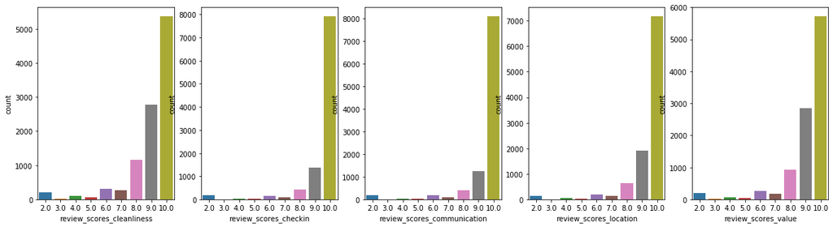

```python
#Review scores
fig,ax= plt.subplots(nrows=1, ncols= 5,figsize=(20,5))

sns.countplot(df_listing['review_scores_cleanliness'],ax=ax[0])

sns.countplot(df_listing['review_scores_checkin'],ax=ax[1])

sns.countplot(df_listing['review_scores_communication'],ax=ax[2])

sns.countplot(df_listing['review_scores_location'],ax=ax[3])

sns.countplot(df_listing['review_scores_value'],ax=ax[4])

plt.show()
```

- All review scores distributing between 2 and 10
- Most of them lying to 8-10
- If review score is Null it means there is no comment

I think i can't fill that value with mean because these listings does not take mean scores. Actually they have no score. But when i'm looking to distribution minimum value is 2 and I decide to fill null values with minimum. Maybe fill nulls with 0 instead of minimum is the another option but i don't want to change the scale of the review scores 2-10 to 0-10.

```python
check_nulls(df_listing)
```

```
review_scores_value            12087
review_scores_checkin          12086
review_scores_accuracy         12086
review_scores_location         12085
review_scores_cleanliness      12083
review_scores_communication    12082
review_scores_rating           12077
reviews_per_month              11599
host_acceptance_rate            8097
host_response_time              6719
host_response_rate              6719
bedrooms                        1872
beds                             693
host_total_listings_count         10
host_is_superhost                 10
host_has_profile_pic              10
host_identity_verified            10
host_since                        10
dtype: int64
```

```python
review_fill_min_cols = ['review_scores_rating','review_scores_accuracy','review_scores_cleanliness',
                        'review_scores_checkin','review_scores_communication','review_scores_location',
                        'review_scores_value']

for col in review_fill_min_cols:
    minimum = min(df_listing[col])
    df_listing[col].fillna(minimum,inplace = True)
```

```python
check_nulls(df_listing)
```

```
reviews_per_month            11599
host_acceptance_rate          8097
host_response_rate            6719
host_response_time            6719
bedrooms                      1872
beds                           693
host_identity_verified          10
host_has_profile_pic            10
host_total_listings_count       10
host_is_superhost               10
host_since                      10
dtype: int64
```

```python
df_listing[df_listing['host_since'].isna()].host_id.unique()

#3 hosts have null values
```

```
array([ 33104525,  20032599, 258013771], dtype=int64)
```

```python
def find_and_fill(df,host_id,column,fill_value):
    '''
    Get the given host_id location in the df dataframe and fill the given column with fill value"""
    '''

    df.loc[df['host_id'] == host_id,column] = fill_value
```

```python
#Manuelly get the values from host_urls
find_and_fill(df_listing, 33104525,'host_since',pd.to_datetime('2015-05-01',format = '%Y-%m-%d'))
find_and_fill(df_listing, 33104525,'host_is_superhost',False)
find_and_fill(df_listing, 33104525,'host_total_listings_count',8)
find_and_fill(df_listing, 33104525,'host_has_profile_pic',True)
find_and_fill(df_listing, 33104525,'host_identity_verified',True)
find_and_fill(df_listing, 33104525,'host_response_rate',100)
find_and_fill(df_listing, 33104525,'host_response_time','within an hour')



find_and_fill(df_listing, 20032599,'host_since',pd.to_datetime('2014-08-01',format = '%Y-%m-%d'))
find_and_fill(df_listing, 20032599,'host_is_superhost',False)
find_and_fill(df_listing, 20032599,'host_total_listings_count',1)
find_and_fill(df_listing, 20032599,'host_has_profile_pic',True)
find_and_fill(df_listing, 20032599,'host_identity_verified',False)
find_and_fill(df_listing, 20032599,'host_response_rate',0)


find_and_fill(df_listing, 258013771,'host_since',pd.to_datetime('2019-04-01',format = '%Y-%m-%d'))
find_and_fill(df_listing, 258013771,'host_is_superhost',False)
find_and_fill(df_listing, 258013771,'host_total_listings_count',1)
find_and_fill(df_listing, 258013771,'host_has_profile_pic',True)
find_and_fill(df_listing, 258013771,'host_identity_verified',False)

df_listing['host_since'] = pd.to_datetime(df_listing['host_since'],format="%Y-%m-%d")

today = pd.to_datetime(df_listing['last_scraped'].max(),format = "%Y-%m-%d")

df_listing['host_tenure'] = today.to_period('M') - df_listing['host_since'].apply(lambda x: x.to_period('M'))
df_listing['host_tenure'] = df_listing['host_tenure'].apply(lambda x: x.n)

df_listing.drop('host_since',axis = 1,inplace = True)
```

```python
check_nulls(df_listing)
```

```
reviews_per_month       11599
host_acceptance_rate     8097
host_response_time       6711
host_response_rate       6710
bedrooms                 1872
beds                      693
dtype: int64
```

- I'm going to fill the beds attribute looking for the bedroom attributes.
  - Because Beds attributes have 693 Null and Bedrooms attributes 1872 Nulls. Filling the beds attributes is more reliable than the bedrooms

Null value filling strategy for bedrooms:

1- take beds mean in the group of bedrooms and fill the beds null variables with mean (For example listing which has 1 bedrooms has 1.4 beds in the average so that assign null values which has 1 bedrooms with round(1.4) = 1

2- When bedrooms and beds variables are null together i decide to fill that values with mean values.

```python
#fill beds column with bedrooms by grouping bedrooms with beds mean and fill that value for each bedrooms
beds = df_listing[['beds','bedrooms']] #Take beds and bedrooms attributes
beds_fill_null = beds.groupby('bedrooms').beds.mean() #Take beds mean according to bedrooms
max_bedroom_count = beds_fill_null.index.max() #Max bedroom count for iteration

#Iterate 1 to max_bedroom_count
#Fill the missing beds values according to bedrooms
for i in range(1,int(max_bedroom_count)):
    try:
        df_listing.loc[(df_listing['bedrooms'] == i) & (df_listing['bedrooms'].notna()),'beds'] = round(beds_fill_null[i])
    except:
        continue

#both beds and bedrooms variables are null
#fill beds with mean
df_listing['beds'].fillna(round(df_listing['beds'].mean()),inplace=True)
df_listing.drop('bedrooms',axis = 1,inplace = True)
```

```python
check_nulls(df_listing)
```

```
reviews_per_month       11599
host_acceptance_rate     8097
host_response_time       6711
host_response_rate       6710
dtype: int64
```

```python
#review_per_month N/A for 0 comments so that i'll fill that value for 0
df_listing['reviews_per_month'].fillna(0,inplace = True)
```

```python
check_nulls(df_listing)
```

```
host_acceptance_rate    8097
host_response_time      6711
host_response_rate      6710
dtype: int64
```

```python
df_listing['host_response_time'].value_counts()
```

```
within an hour        9489
a few days or more    2255
within a few hours    1995
within a day          1878
Name: host_response_time, dtype: int64
```

```python
df_listing.host_response_rate = df_listing.host_response_rate.fillna('0%')
df_listing.host_acceptance_rate = df_listing.host_acceptance_rate.fillna('0%')
df_listing.drop('host_response_time',axis = 1,inplace =True)
```

```python
df_listing['host_response_rate'] = perc_to_float(df_listing, 'host_response_rate')
df_listing['host_acceptance_rate'] = perc_to_float(df_listing, 'host_acceptance_rate')
```

```python
check_nulls(df_listing)
```

```
Series([], dtype: int64)
```

```python
european_side = ['Beyoglu', 'Sisli', 'Fatih', 'Besiktas',
       'Esenyurt', 'Kagithane',   'Sariyer',
       'Bakirkoy', 'Basaksehir', 'Avcilar',  'Eyup',
       'Bahcelievler', 'Kucukcekmece',  'Bagcilar',
        'Zeytinburnu', 'Buyukcekmece', 'Beylikduzu',
        'Arnavutkoy', 'Gaziosmanpasa', 'Gungoren',
        'Silivri', 'Esenler', 'Bayrampasa', 'Catalca',
       'Sultangazi', ]

asian_side = ['Kadikoy','Uskudar','Maltepe','Atasehir',
              'Pendik','Umraniye','Sile','Adalar','Kartal',
              'Beykoz','Tuzla','Sancaktepe','Sultanbeyli', 'Cekmekoy']

centers = ['Beyoglu','Sisli','Fatih','Besiktas','Sariyer','Kadikoy','Uskudar','Adalar','Beykoz']
```

```python
df_listing.loc[df_listing['neighbourhood_cleansed'].isin(european_side),'continent'] = 'europa'
df_listing.loc[df_listing['neighbourhood_cleansed'].isin(asian_side),'continent'] = 'asia'

df_listing.loc[df_listing['neighbourhood_cleansed'].isin(centers),'center_flag'] = 1
df_listing.loc[~df_listing['neighbourhood_cleansed'].isin(centers),'center_flag'] = 0
```

```python
bool_cols = ['host_is_superhost','host_has_profile_pic','host_identity_verified']

for col in bool_cols:
    df_listing[col] = df_listing[col].astype(int)
```

```python
df_listing.head()
```

|  | id | last_scraped | host_id | host_url | host_response_rate | host_acceptance_rate | host_is_superhost | host_total_listings_count | host_has_profile_pic | host_identity_verified | neighbourhood_cleansed | room_type | accommodates | beds | price | minimum_nights | maximum_nights | minimum_minimum_nights | maximum_minimum_nights | minimum_maximum_nights | maximum_maximum_nights | minimum_nights_avg_ntm | maximum_nights_avg_ntm | has_availability | availability_30 | availability_60 | availability_90 | availability_365 | calendar_last_scraped | … |
| --- | --- | --- | --- | --- | --- | --- | --- | --- | --- | --- | --- | --- | --- | --- | --- | --- | --- | --- | --- | --- | --- | --- | --- | --- | --- | --- | --- | --- | --- | --- |
| 0 | 20815 | 2020-10-27 | 78838 | https://www.airbnb.com/users/show/78838 | 0.0 | 0.0 | 0 | 2.0 | 1 | 0 | Besiktas | Entire home/apt | 3 | 3.0 | 965.0 | 365 | 900 | 365 | 365 | 900 | 900 | 365.0 | 900.0 | True | 21 | 51 | 81 | 356 | 2020-10-27 | … |
| 1 | 27271 | 2020-10-28 | 117026 | https://www.airbnb.com/users/show/117026 | 0.0 | 0.0 | 0 | 1.0 | 1 | 1 | Beyoglu | Entire home/apt | 2 | 1.0 | 289.0 | 30 | 90 | 30 | 30 | 90 | 90 | 30.0 | 90.0 | True | 0 | 0 | 0 | 0 | 2020-10-28 | … |
| 2 | 28318 | 2020-10-28 | 121721 | https://www.airbnb.com/users/show/121721 | 0.0 | 0.0 | 0 | 1.0 | 1 | 1 | Sariyer | Entire home/apt | 2 | 3.0 | 1018.0 | 3 | 60 | 3 | 3 | 60 | 60 | 3.0 | 60.0 | True | 28 | 58 | 88 | 88 | 2020-10-28 | … |
| 3 | 29241 | 2020-10-28 | 125742 | https://www.airbnb.com/users/show/125742 | 0.0 | 0.0 | 0 | 1.0 | 1 | 0 | Beyoglu | Private room | 3 | 1.0 | 407.0 | 3 | 15 | 3 | 3 | 15 | 15 | 3.0 | 15.0 | True | 30 | 60 | 90 | 365 | 2020-10-28 | … |
| 4 | 30697 | 2020-10-27 | 132137 | https://www.airbnb.com/users/show/132137 | 0.0 | 0.0 | 0 | 1.0 | 1 | 1 | Beyoglu | Private room | 2 | 1.0 | 952.0 | 1 | 2 | 1 | 1 | 2 | 2 | 1.0 | 2.0 | True | 29 | 59 | 89 | 364 | 2020-10-27 | … |

### Some Descriptions

```python
len(df_listing.host_id.unique())
```

```
12651
```

```
''
```

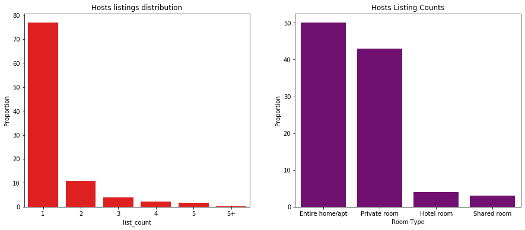

```python
host_list_counts = df_listing.groupby('host_id').id.size().reset_index()
host_list_counts.columns = ['host_id','list_count']
host_list_counts = host_list_counts.groupby('list_count').host_id.count().reset_index()
host_list_counts.columns = ['list_count','Count Host']
host_list_counts['Proportion'] = (host_list_counts['Count Host'] / host_list_counts['Count Host'].sum())*100
host_list_counts.loc[host_list_counts['list_count'] > 5, 'list_count'] = '5+'

room_types = round((df_listing.room_type.value_counts() / df_listing.shape[0])*100).reset_index()
room_types.columns = ['Room Type','Proportion']


fig, ax = plt.subplots(1,2,figsize = (15,6))
sns.barplot(x = 'list_count', y = 'Proportion', data = host_list_counts,color = 'red', ax = ax[0])
ax[0].set_title('Hosts listings distribution')
;

sns.barplot(x = 'Room Type', y = 'Proportion', data = room_types,color = 'purple',ax = ax[1])
ax[1].set_title('Hosts Listing Counts')
;
```

- Here is my first questions answer! There is nearly 80% of the hosts have 1 listing in Airbnb app
- Hotel rooms and shared room has small part of all listings

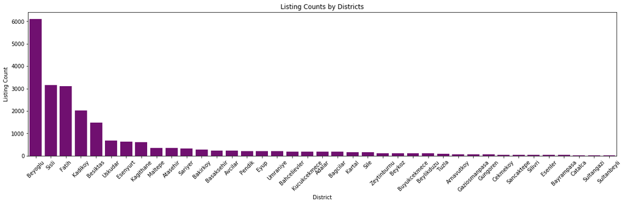

```python
districts = df_listing.groupby('neighbourhood_cleansed').size().sort_values(ascending = False).reset_index()
districts.columns = ['District','Listing Count']

plt.figure(figsize=(20,5))
sns.barplot(x = 'District',y = 'Listing Count', data = districts, color='purple')
plt.title('Listing Counts by Districts')
plt.xticks(rotation = 45);
```

Beyoglu, Sisli, Fatih Kadikoy has most of the listings because Beyoglu is the most popular district in Istanbul. It is very normal

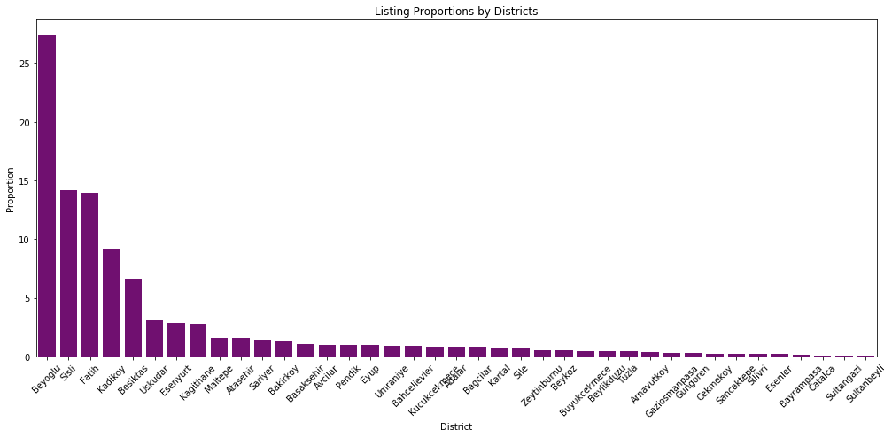

```python
districts = (df_listing.groupby('neighbourhood_cleansed').size() / df_listing.shape[0]*100).sort_values(ascending = False).reset_index()
districts.columns = ['District','Listing Count']

plt.figure(figsize=(17,7))
sns.barplot(x = 'District',y = 'Listing Count', data = districts, color='purple')
plt.title('Listing Proportions by Districts')
plt.ylabel('Proportion')
plt.xticks(rotation = 45);
```

District distribution by percentage. Beyoglu has more than 25%

```python
df_listing[df_listing['host_is_superhost'] == 1].shape
```

```
(2819, 69)
```

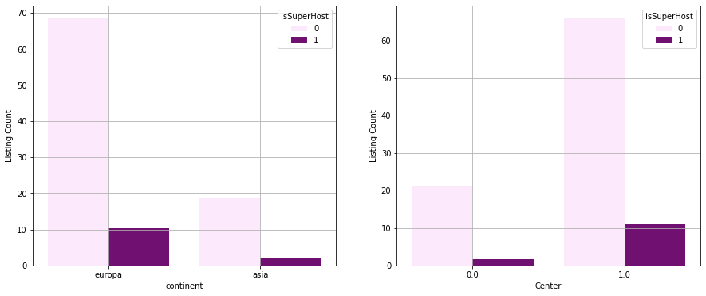

```python
continents = (df_listing.groupby(['continent','host_is_superhost']).size() / df_listing.shape[0]*100).sort_values(ascending = False).reset_index()
continents.columns = ['continent','isSuperHost','Listing Count']

centers = (df_listing.groupby(['center_flag','host_is_superhost']).size() / df_listing.shape[0]*100).sort_values(ascending = False).reset_index()
centers.columns = ['Center','isSuperHost','Listing Count']




fig, ax = plt.subplots(1,2,figsize = (15,6))

sns.barplot(x = 'continent',y = 'Listing Count', hue = 'isSuperHost',data = continents, color='purple',ax = ax[0])

ax[0].grid()

sns.barplot(x = 'Center',y = 'Listing Count', hue = 'isSuperHost', data = centers, color='purple',ax = ax[1]);
ax[1].grid()
```

Most of the listings are located in European Side of Istanbul and Super hosts are ~10% of all listings. Also European side has more superHosts than asian side

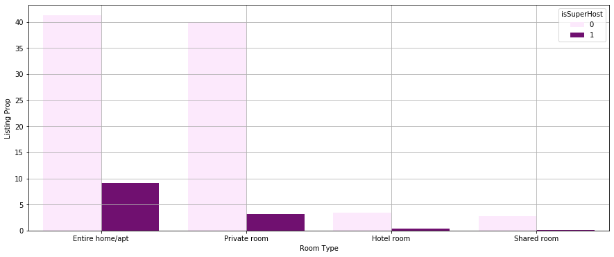

```python
room_type = (df_listing.groupby(['room_type','host_is_superhost']).size() / df_listing.shape[0]*100).sort_values(ascending = False).reset_index()
room_type.columns = ['Room Type','isSuperHost','Listing Prop']

plt.figure(figsize = (15,6))
sns.barplot(x = 'Room Type',y = 'Listing Prop',hue = 'isSuperHost', data = room_type, color='purple');
plt.grid()
```

Generally Super hosts are listing their Entire Apts.

### Investigate Price Distributions

```python
price_desc = df_listing.describe()['price']
```

```
Minimum: 0.00, Maximum: 157693.00, Mean: 511.83, std : 1904.44
```

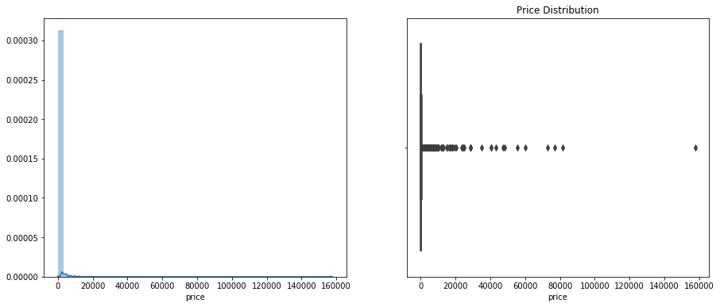

```python
fig , ax = plt.subplots(1,2, figsize = (15,6))
plt.title('Price Distribution')
sns.distplot(df_listing['price'],ax = ax[0]);
sns.boxplot(df_listing['price'],ax = ax[1])
print("Minimum: {:.2f}, Maximum: {:.2f}, Mean: {:.2f}, std : {:.2f} ".format(price_desc['min'],price_desc['max'],price_desc['mean'],price_desc['std']))
```

Price is right skewed and distributing with mean of 511 and std 1904. There is high variance in price attribute

```
Minimum: 0.00, Maximum: 157693.00, Mean: 511.83, std : 1904.44
```

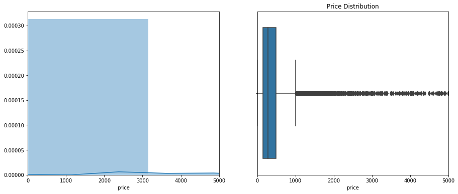

```python
fig , ax = plt.subplots(1,2, figsize = (15,6))
plt.title('Price Distribution')
sns.distplot(df_listing['price'],ax = ax[0]);
sns.boxplot(df_listing['price'],ax = ax[1])
print("Minimum: {:.2f}, Maximum: {:.2f}, Mean: {:.2f}, std : {:.2f} ".format(price_desc['min'],price_desc['max'],price_desc['mean'],price_desc['std']))

ax[0].set_xlim(0,5000)
ax[1].set_xlim(0,5000);
```

price is highly right skewed and there is some potential outliers, nearly 160K Turkish Lira there is absolute outlier I'm gonna drop it

```
Minimum: 0.00, Maximum: 157693.00, Mean: 511.83, std : 1904.44
```

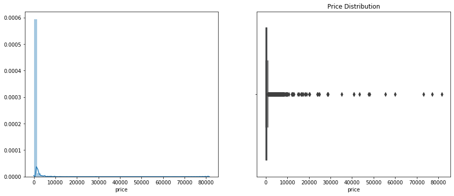

```python
df_listing = df_listing[df_listing['price'] < 150000]

fig , ax = plt.subplots(1,2, figsize = (15,6))
plt.title('Price Distribution')
sns.distplot(df_listing['price'],ax = ax[0]);
sns.boxplot(df_listing['price'],ax = ax[1])
print("Minimum: {:.2f}, Maximum: {:.2f}, Mean: {:.2f}, std : {:.2f} ".format(price_desc['min'],price_desc['max'],price_desc['mean'],price_desc['std']))
```

After dropped the most extreme point from the data check the distribution again. Probably we can deal with the other extreme points with log transformation. So In the Modeling part we are going to solve this problem

```python
df_listing.head()
```

|  | id | last_scraped | host_id | host_url | host_response_rate | host_acceptance_rate | host_is_superhost | host_total_listings_count | host_has_profile_pic | host_identity_verified | neighbourhood_cleansed | room_type | accommodates | beds | price | minimum_nights | maximum_nights | minimum_minimum_nights | maximum_minimum_nights | minimum_maximum_nights | maximum_maximum_nights | minimum_nights_avg_ntm | maximum_nights_avg_ntm | has_availability | availability_30 | availability_60 | availability_90 | availability_365 | calendar_last_scraped | … |
| --- | --- | --- | --- | --- | --- | --- | --- | --- | --- | --- | --- | --- | --- | --- | --- | --- | --- | --- | --- | --- | --- | --- | --- | --- | --- | --- | --- | --- | --- | --- |
| 0 | 20815 | 2020-10-27 | 78838 | https://www.airbnb.com/users/show/78838 | 0.0 | 0.0 | 0 | 2.0 | 1 | 0 | Besiktas | Entire home/apt | 3 | 3.0 | 965.0 | 365 | 900 | 365 | 365 | 900 | 900 | 365.0 | 900.0 | True | 21 | 51 | 81 | 356 | 2020-10-27 | … |
| 1 | 27271 | 2020-10-28 | 117026 | https://www.airbnb.com/users/show/117026 | 0.0 | 0.0 | 0 | 1.0 | 1 | 1 | Beyoglu | Entire home/apt | 2 | 1.0 | 289.0 | 30 | 90 | 30 | 30 | 90 | 90 | 30.0 | 90.0 | True | 0 | 0 | 0 | 0 | 2020-10-28 | … |
| 2 | 28318 | 2020-10-28 | 121721 | https://www.airbnb.com/users/show/121721 | 0.0 | 0.0 | 0 | 1.0 | 1 | 1 | Sariyer | Entire home/apt | 2 | 3.0 | 1018.0 | 3 | 60 | 3 | 3 | 60 | 60 | 3.0 | 60.0 | True | 28 | 58 | 88 | 88 | 2020-10-28 | … |
| 3 | 29241 | 2020-10-28 | 125742 | https://www.airbnb.com/users/show/125742 | 0.0 | 0.0 | 0 | 1.0 | 1 | 0 | Beyoglu | Private room | 3 | 1.0 | 407.0 | 3 | 15 | 3 | 3 | 15 | 15 | 3.0 | 15.0 | True | 30 | 60 | 90 | 365 | 2020-10-28 | … |
| 4 | 30697 | 2020-10-27 | 132137 | https://www.airbnb.com/users/show/132137 | 0.0 | 0.0 | 0 | 1.0 | 1 | 1 | Beyoglu | Private room | 2 | 1.0 | 952.0 | 1 | 2 | 1 | 1 | 2 | 2 | 1.0 | 2.0 | True | 29 | 59 | 89 | 364 | 2020-10-27 | … |

```python
bool_vars = ['host_is_superhost','host_has_profile_pic','host_identity_verified','has_availability','continent','host_verifications_email', 'host_verifications_ phone',
       'host_verifications_ government_id', 'host_verifications_ reviews',
       'host_verifications_ offline_government_id',
       'host_verifications_ jumio', 'host_verifications_ selfie',
       'host_verifications_ facebook', 'host_verifications_ work_email',
       'host_verifications_ identity_manual', 'amenities_ Heating',
       'amenities_ Kitchen', 'amenities_ Hair dryer', 'amenities_ TV',
       'amenities_ Iron', 'amenities_ Shampoo', 'amenities_ Hangers',
       'amenities_ Washer', 'amenities_ Wifi',
       'amenities_ Laptop-friendly workspace']
```

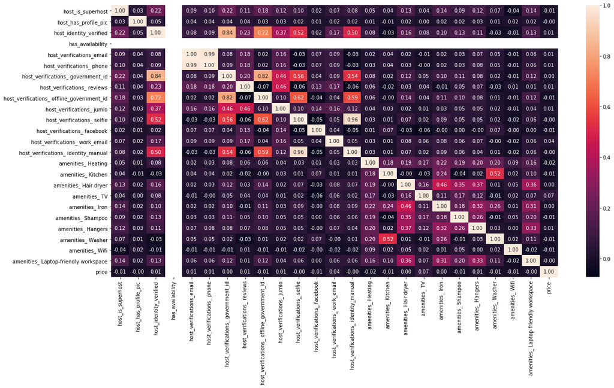

```python
plt.figure(figsize = (20,10))
corr_booleans = df_listing[bool_vars + ['price']].corr()
sns.heatmap(corr_booleans,annot=True,fmt = '.2f')
```

There is no obvious relation in price and host and amenities related attributes

```python
df_listing.drop(['host_verifications_ government_id',
                 'host_verifications_ offline_government_id','host_verifications_ selfie'],axis = 1,inplace = True)
```

```python
df_listing.drop(['has_availability','host_identity_verified'],axis = 1,inplace = True)
```

```python
numeric_cols = ['host_response_rate','host_acceptance_rate',
                'host_total_listings_count','accommodates','beds','minimum_nights',
                'maximum_nights','minimum_minimum_nights','maximum_minimum_nights',
                'minimum_maximum_nights','maximum_maximum_nights',
                'minimum_nights_avg_ntm','maximum_nights_avg_ntm','availability_30',
                'availability_60','availability_90','availability_365','number_of_reviews',
                'number_of_reviews_ltm','number_of_reviews_l30d','review_scores_rating',
                'review_scores_accuracy','review_scores_cleanliness','review_scores_checkin','review_scores_checkin',
                'review_scores_communication','review_scores_location','review_scores_value','calculated_host_listings_count',
                'calculated_host_listings_count_entire_homes','calculated_host_listings_count_private_rooms',
                'calculated_host_listings_count_shared_rooms','reviews_per_month','bathroom','host_tenure',
                'price']
```

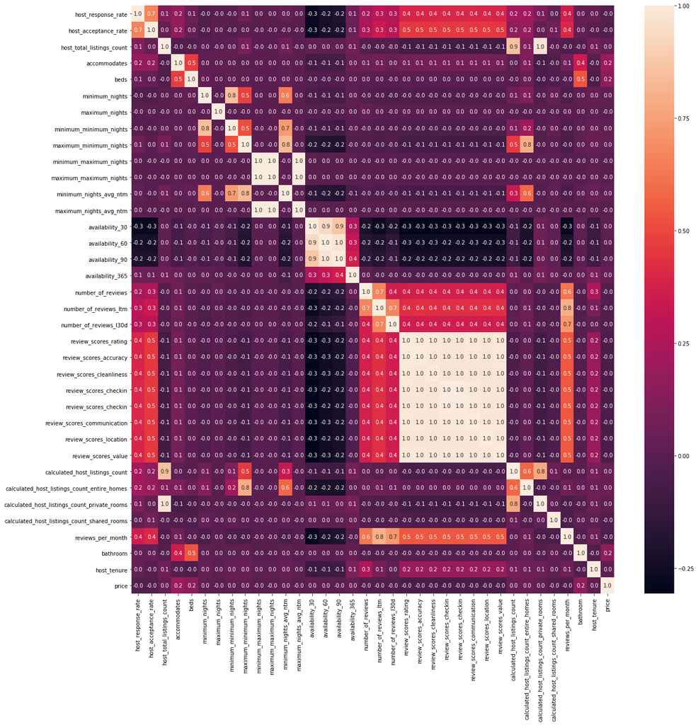

```python
corr = df_listing[numeric_cols].corr()

plt.figure(figsize = (20,20))
sns.heatmap(corr,annot = True,fmt='.1f');
```

- price is slightly correlated with accomodates,beds bathroom
- host response rate and host acceptance rates are highly correlated
- host_total_listing_count highly correlated with calculated_host_listings_count and calculated_host_count_private_rooms
- minimum_nights is highly correlated with minimum_minimum_nights
- review scores are full correlated
- availabilities are correlated each other

```python
numeric_drop_cols = ['host_acceptance_rate',
                'minimum_minimum_nights','maximum_minimum_nights',
                'minimum_maximum_nights','maximum_maximum_nights',
                'minimum_nights_avg_ntm','maximum_nights_avg_ntm',
                'availability_60','availability_90','availability_365',
                'number_of_reviews_ltm','number_of_reviews_l30d',
                'review_scores_accuracy','review_scores_cleanliness','review_scores_checkin','review_scores_checkin',
                'review_scores_communication','review_scores_location','review_scores_value','calculated_host_listings_count',
                'calculated_host_listings_count_private_rooms',
                'calculated_host_listings_count_shared_rooms']
```

```python
df_model = df_listing.copy()
```

```python
df_model.drop(numeric_drop_cols,axis = 1,inplace=True)
```

```python
df_model.head()
```

|  | id | last_scraped | host_id | host_url | host_response_rate | host_is_superhost | host_total_listings_count | host_has_profile_pic | neighbourhood_cleansed | room_type | accommodates | beds | price | minimum_nights | maximum_nights | availability_30 | calendar_last_scraped | number_of_reviews | review_scores_rating | instant_bookable | calculated_host_listings_count_entire_homes | reviews_per_month | host_verifications_email | host_verifications_ phone | host_verifications_ reviews | host_verifications_ jumio | host_verifications_ facebook | host_verifications_ work_email | host_verifications_ identity_manual | … |
| --- | --- | --- | --- | --- | --- | --- | --- | --- | --- | --- | --- | --- | --- | --- | --- | --- | --- | --- | --- | --- | --- | --- | --- | --- | --- | --- | --- | --- | --- | --- |
| 0 | 20815 | 2020-10-27 | 78838 | https://www.airbnb.com/users/show/78838 | 0.0 | 0 | 2.0 | 1 | Besiktas | Entire home/apt | 3 | 3.0 | 965.0 | 365 | 900 | 21 | 2020-10-27 | 41 | 90.0 | False | 1 | 0.32 | 1.0 | 1.0 | 1.0 | 0.0 | 1.0 | 1.0 | 0.0 | … |
| 1 | 27271 | 2020-10-28 | 117026 | https://www.airbnb.com/users/show/117026 | 0.0 | 0 | 1.0 | 1 | Beyoglu | Entire home/apt | 2 | 1.0 | 289.0 | 30 | 90 | 0 | 2020-10-28 | 10 | 98.0 | False | 1 | 0.32 | 1.0 | 1.0 | 1.0 | 1.0 | 1.0 | 0.0 | 0.0 | … |
| 2 | 28318 | 2020-10-28 | 121721 | https://www.airbnb.com/users/show/121721 | 0.0 | 0 | 1.0 | 1 | Sariyer | Entire home/apt | 2 | 3.0 | 1018.0 | 3 | 60 | 28 | 2020-10-28 | 0 | 20.0 | False | 1 | 0.00 | 1.0 | 1.0 | 1.0 | 1.0 | 0.0 | 0.0 | 0.0 | … |
| 3 | 29241 | 2020-10-28 | 125742 | https://www.airbnb.com/users/show/125742 | 0.0 | 0 | 1.0 | 1 | Beyoglu | Private room | 3 | 1.0 | 407.0 | 3 | 15 | 30 | 2020-10-28 | 0 | 20.0 | False | 0 | 0.00 | 1.0 | 1.0 | 0.0 | 0.0 | 1.0 | 0.0 | 0.0 | … |
| 4 | 30697 | 2020-10-27 | 132137 | https://www.airbnb.com/users/show/132137 | 0.0 | 0 | 1.0 | 1 | Beyoglu | Private room | 2 | 1.0 | 952.0 | 1 | 2 | 29 | 2020-10-27 | 1 | 80.0 | True | 0 | 0.01 | 0.0 | 0.0 | 1.0 | 1.0 | 0.0 | 0.0 | 0.0 | … |

```python
df_graph = df_model.copy()
```

```
(0, 2000)
```

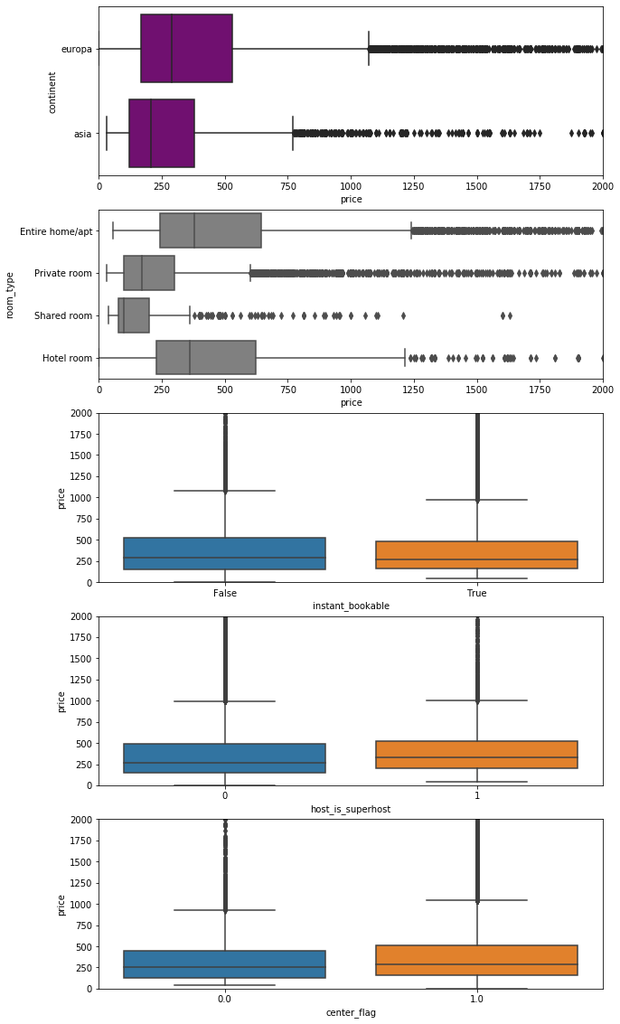

```python
fig, ax = plt.subplots(5,1,figsize = (10,20))

sns.boxplot(x = 'price', y = 'continent', data = df_graph, ax = ax[0], color = 'purple')
ax[0].set_xlim(0,2000)

sns.boxplot(x = 'price', y = 'room_type', data = df_graph, ax = ax[1], color = 'grey')
ax[1].set_xlim(0,2000)


sns.boxplot(y = 'price', x = 'instant_bookable', data = df_graph, ax = ax[2])
ax[2].set_ylim(0,2000)

sns.boxplot(y = 'price', x = 'host_is_superhost', data = df_graph, ax = ax[3])
ax[3].set_ylim(0,2000)

sns.boxplot(y = 'price', x = 'center_flag', data = df_graph, ax = ax[4])
ax[4].set_ylim(0,2000)
```

europe has higher price than asia, entire homes are likely to hotel rooms price than entire homes are very comfortable i think actually prices are not depend on instan bookable, superhost,center or not center

```python
df_model.drop(['instant_bookable','host_is_superhost','center_flag','neighbourhood_cleansed'],axis = 1,inplace = True)
```

```python
#add dummy variables of room_type and continent
df_model = df_model.join(pd.get_dummies(df_model['room_type'],drop_first=True)).drop('room_type',axis = 1)
df_model = df_model.join(pd.get_dummies(df_model['continent'],drop_first = True)).drop('continent',axis = 1)
```

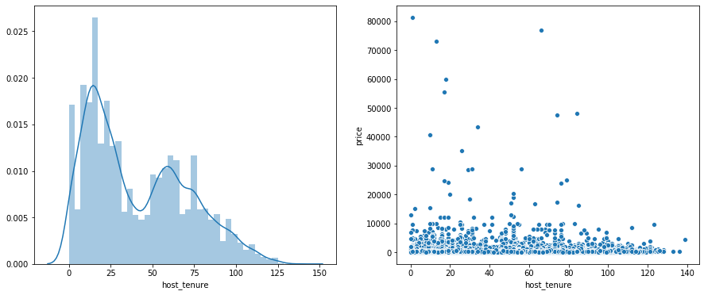

```python
#Distribution of host tenure
fig, ax = plt.subplots(1,2,figsize = (15,6))
sns.distplot(df_model['host_tenure'],ax = ax[0])
sns.scatterplot('host_tenure','price',data = df_model,ax = ax[1]);
```

based on host tenure attribute there is 2 group i have seen in the distplot

```python
#Change host_tenure to old_host 1,0 Format
df_model.loc[df_model['host_tenure'] >= 40,'old_host'] = 1
df_model.loc[df_model['host_tenure'] < 40,'old_host'] = 0
df_model.drop('host_tenure',axis = 1,inplace = True)
```

```
(0, 2000)
```

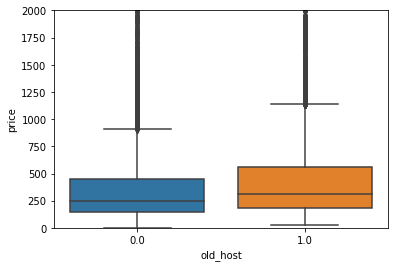

```python
sns.boxplot(x = 'old_host',y = 'price', data = df_model)
plt.ylim(0,2000)
```

price distribution according to hosts tenure in airbnb

```python
#Convert host_response_rate to 1,0 Format because distribution of host_response stacks in 0 or 100
df_model.loc[df_model['host_response_rate'] >= 50,'frequent_response'] = 1
df_model.loc[df_model['host_response_rate'] < 50,'frequent_response'] = 0
df_model.drop('host_response_rate',axis = 1,inplace = True)
```

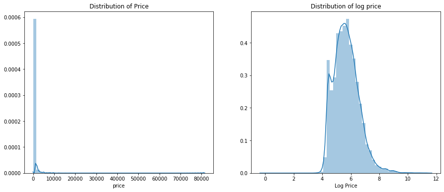

```python
#Transform variable price to log(price) for normality
fig, ax = plt.subplots(1,2,figsize = (15,6))
sns.distplot(df_model.price,ax = ax[0]);
sns.distplot(np.log1p(df_model.price),ax = ax[1]);
ax[0].set_title('Distribution of Price')
ax[1].set_title('Distribution of log price');
ax[1].set_xlabel('Log Price');
```

Transform price to log price for normality

```python
#drop unnecessary columns
drop_cols = ['id', 'last_scraped','host_id','host_url','calendar_last_scraped']

for col in drop_cols:
    df_model.drop(col,axis = 1, inplace = True)
```

## Data Modeling

```python
df_model.head()
```

|  | host_total_listings_count | host_has_profile_pic | accommodates | beds | price | minimum_nights | maximum_nights | availability_30 | number_of_reviews | review_scores_rating | calculated_host_listings_count_entire_homes | reviews_per_month | host_verifications_email | host_verifications_ phone | host_verifications_ reviews | host_verifications_ jumio | host_verifications_ facebook | host_verifications_ work_email | host_verifications_ identity_manual | amenities_ Heating | amenities_ Kitchen | amenities_ Hair dryer | amenities_ TV | amenities_ Iron | amenities_ Shampoo | amenities_ Hangers | amenities_ Washer | amenities_ Wifi | amenities_ Laptop-friendly workspace | … |
| --- | --- | --- | --- | --- | --- | --- | --- | --- | --- | --- | --- | --- | --- | --- | --- | --- | --- | --- | --- | --- | --- | --- | --- | --- | --- | --- | --- | --- | --- | --- |
| 0 | 2.0 | 1 | 3 | 3.0 | 965.0 | 365 | 900 | 21 | 41 | 90.0 | 1 | 0.32 | 1.0 | 1.0 | 1.0 | 0.0 | 1.0 | 1.0 | 0.0 | 1.0 | 1.0 | 1.0 | 1.0 | 1.0 | 1.0 | 1.0 | 1.0 | 0.0 | 1.0 | … |
| 1 | 1.0 | 1 | 2 | 1.0 | 289.0 | 30 | 90 | 0 | 10 | 98.0 | 1 | 0.32 | 1.0 | 1.0 | 1.0 | 1.0 | 1.0 | 0.0 | 0.0 | 1.0 | 1.0 | 1.0 | 1.0 | 1.0 | 1.0 | 1.0 | 1.0 | 0.0 | 1.0 | … |
| 2 | 1.0 | 1 | 2 | 3.0 | 1018.0 | 3 | 60 | 28 | 0 | 20.0 | 1 | 0.00 | 1.0 | 1.0 | 1.0 | 1.0 | 0.0 | 0.0 | 0.0 | 1.0 | 1.0 | 0.0 | 0.0 | 0.0 | 1.0 | 0.0 | 1.0 | 1.0 | 0.0 | … |
| 3 | 1.0 | 1 | 3 | 1.0 | 407.0 | 3 | 15 | 30 | 0 | 20.0 | 0 | 0.00 | 1.0 | 1.0 | 0.0 | 0.0 | 1.0 | 0.0 | 0.0 | 0.0 | 1.0 | 0.0 | 1.0 | 0.0 | 1.0 | 0.0 | 1.0 | 1.0 | 0.0 | … |
| 4 | 1.0 | 1 | 2 | 1.0 | 952.0 | 1 | 2 | 29 | 1 | 80.0 | 0 | 0.01 | 0.0 | 0.0 | 1.0 | 1.0 | 0.0 | 0.0 | 0.0 | 1.0 | 1.0 | 1.0 | 1.0 | 0.0 | 0.0 | 0.0 | 1.0 | 1.0 | 0.0 | … |

```python
# X,y seperation
X = df_model.drop('price',axis = 1)
y = np.log1p(df_model.price)
```

```python
# Scale independent variables
scaler = StandardScaler()
X = scaler.fit_transform(X)
```

```python
#Random forest fit
lm_model = RandomForestRegressor(max_depth = 9,random_state = 42)
lm_model.fit(X,y)
```

```
RandomForestRegressor(bootstrap=True, criterion='mse', max_depth=9,
           max_features='auto', max_leaf_nodes=None,
           min_impurity_decrease=0.0, min_impurity_split=None,
           min_samples_leaf=1, min_samples_split=2,
           min_weight_fraction_leaf=0.0, n_estimators=10, n_jobs=None,
           oob_score=False, random_state=42, verbose=0, warm_start=False)
```

```python
#predict
pred = lm_model.predict(X)
```

```
r2 Score: 0.58, MSE : 0.32
```

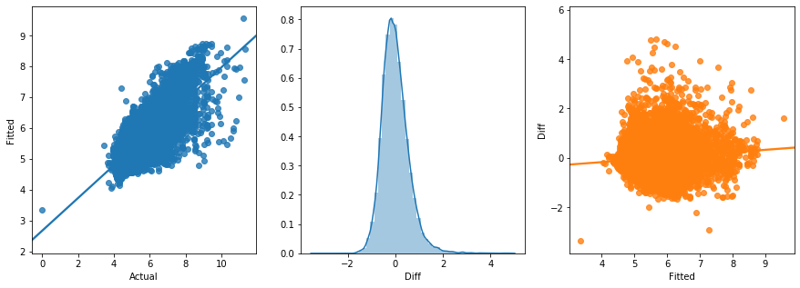

```python
#show results
result = actual_vs_predicted(y,pred)
```

- Error has normal distribution
- When the price increasing price diverging
- There is potential outliers

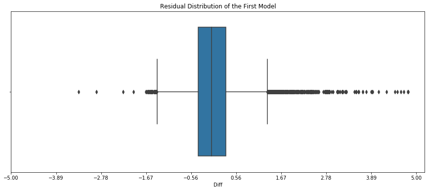

```python
#Error distribution
plt.figure(figsize = (15,6))
plt.title('Residual Distribution of the First Model')
sns.boxplot(result['Diff'])
plt.xticks(np.linspace(-5,5,10));
```

I'm going to delete the outliers

```python
#Outlier detection
outliers = result[(result['Diff'] >= 1.7) | (result['Diff'] <= -1.7)]
```

```python
len(outliers.index)
```

```
242
```

```python
#Drop outliers
df_model_dropped = df_model.drop(outliers.index)
```

```python
#X,y seperation again
X = df_model_dropped.drop('price',axis = 1)
y = np.log1p(df_model_dropped.price)
```

```python
#Train Test split
X_train,X_test,y_train,y_test = train_test_split(X,y,test_size = 0.3,random_state = 123)
```

```python
#Fit X_train to scaler and just transform X_test with the scaler which i created
scaler = StandardScaler()
X_train = scaler.fit_transform(X_train)
X_test = scaler.transform(X_test)
```

```python
#Random Forest Again
lm_model = RandomForestRegressor(max_depth = 9, random_state = 42)
lm_model.fit(X_train,y_train)
```

```
RandomForestRegressor(bootstrap=True, criterion='mse', max_depth=9,
           max_features='auto', max_leaf_nodes=None,
           min_impurity_decrease=0.0, min_impurity_split=None,
           min_samples_leaf=1, min_samples_split=2,
           min_weight_fraction_leaf=0.0, n_estimators=10, n_jobs=None,
           oob_score=False, random_state=42, verbose=0, warm_start=False)
```

```python
#Get predictions
pred_train = lm_model.predict(X_train)
pred_test = lm_model.predict(X_test)
```

```
r2 Score: 0.62, MSE : 0.26
```

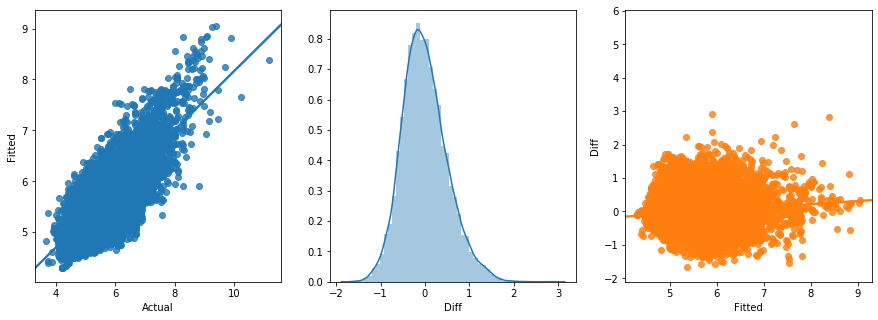

```python
#Train set Results
results = actual_vs_predicted(y_train,pred_train)
```

Train set Results show that there is 0.62 R2 Score and 0.26MSE

```
r2 Score: 0.56, MSE : 0.31
```

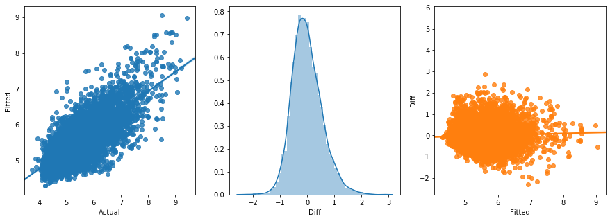

|  | Actual | Fitted | Diff |
| --- | --- | --- | --- |
| 0 | 5.655992 | 5.813480 | -0.157488 |
| 1 | 4.718499 | 5.851527 | -1.133029 |
| 2 | 4.110874 | 4.794410 | -0.683537 |
| 3 | 4.969813 | 5.510870 | -0.541057 |
| 4 | 5.624018 | 5.871754 | -0.247737 |
| ... | ... | ... | ... |
| 6621 | 4.499810 | 4.569115 | -0.069306 |
| 6622 | 7.384610 | 6.876392 | 0.508218 |
| 6623 | 5.147494 | 5.701028 | -0.553533 |
| 6624 | 4.418841 | 5.228109 | -0.809269 |
| 6625 | 6.386879 | 5.950017 | 0.436863 |

6626 rows × 3 columns

```python
#Test Set Results
actual_vs_predicted(y_test,pred_test)
```

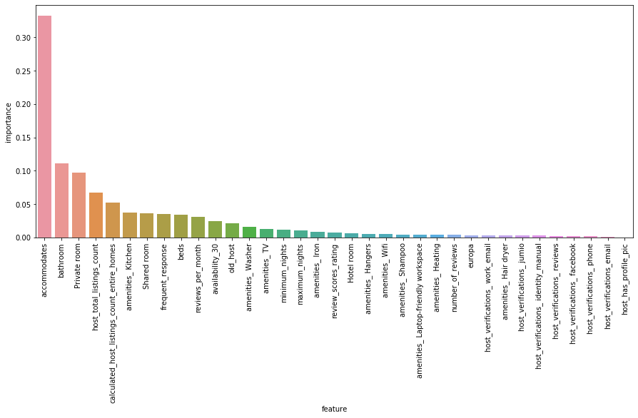

```python
#Feature Importances
importances = pd.DataFrame(list(zip(X.columns,lm_model.feature_importances_)),columns = ['feature','importance'])

plt.figure(figsize = (15,6))
sns.barplot(x = 'feature',y = 'importance', data = importances.sort_values(by = 'importance',ascending = False))
plt.xticks(rotation = 90);
```

accomodates, bathroom, private room, total listing counts, and calculated host listings count entire homes attributes are the 5 most important features

XGB

Now let's try XGB regressor

```python
#Create XGB Regressor
xgb_r = xg.XGBRegressor(objective ='reg:squarederror',
                  n_estimators = 50, seed = 123)
```

```python
#Fit and get results
xgb_r.fit(X_train, y_train)

# Predict the model
pred = xgb_r.predict(X_test)

# RMSE Computation
print("R2Score : % f" %(r2_score(y_test,pred)))
print("MSE : % f" %(mean_squared_error(y_test,pred)))
```

```
R2Score :  0.598804
MSE :  0.282516
```

```
r2 Score: 0.60, MSE : 0.28
```

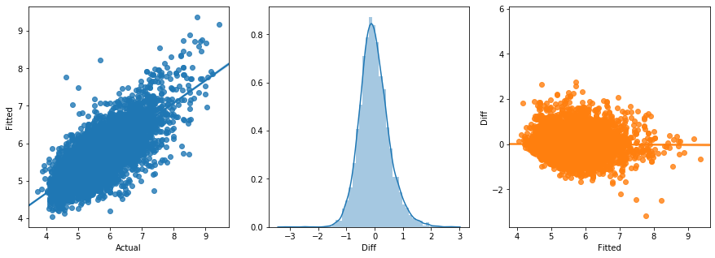

|  | Actual | Fitted | Diff |
| --- | --- | --- | --- |
| 0 | 5.655992 | 5.778031 | -0.122039 |
| 1 | 4.718499 | 5.724648 | -1.006149 |
| 2 | 4.110874 | 4.751279 | -0.640405 |
| 3 | 4.969813 | 5.810310 | -0.840497 |
| 4 | 5.624018 | 6.013915 | -0.389897 |
| ... | ... | ... | ... |
| 6621 | 4.499810 | 4.475555 | 0.024255 |
| 6622 | 7.384610 | 7.222631 | 0.161979 |
| 6623 | 5.147494 | 5.379427 | -0.231932 |
| 6624 | 4.418841 | 5.290440 | -0.871599 |
| 6625 | 6.386879 | 6.209041 | 0.177838 |

6626 rows × 3 columns

```python
#result with test
actual_vs_predicted(y_test,pred)
```

It is better than the RF Regression so that I'm going to select XGB Regression for the prediction

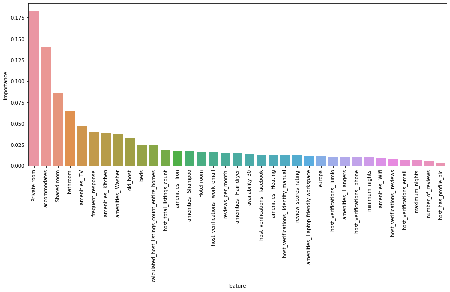

```python
#feature importances
importances = pd.DataFrame(list(zip(X.columns,xgb_r.feature_importances_)),columns = ['feature','importance'])

plt.figure(figsize = (15,6))
sns.barplot(x = 'feature',y = 'importance', data = importances.sort_values(by = 'importance',ascending = False))
plt.xticks(rotation = 90);
```

For the XGB Regression Private room, accomodates,sharedroom, bathroom and TV Amenities are the 5 most important features

# Evaluation

## Question 1: How many hosts have more than 1 listings?

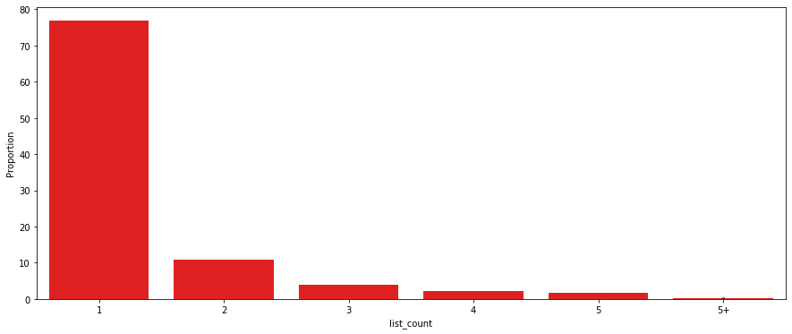

```python
plt.figure(figsize = (15,6))
sns.barplot(x = 'list_count', y = 'Proportion', data = host_list_counts,color = 'red');
```

As you can see the bar plot. Nearly 80% of the hosts have 1 listings in Airbnb. As a result 20% of the hosts have more than 1 listings in app

## Question 2: Is Continent related to prices?

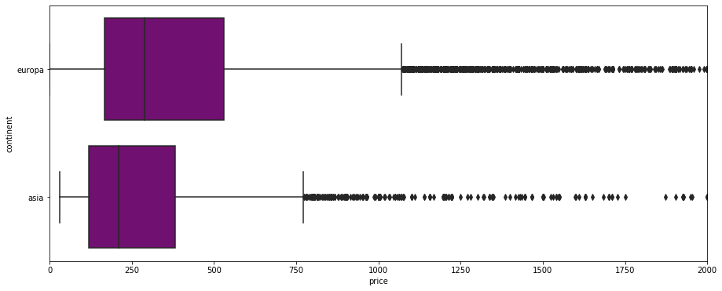

```python
plt.figure(figsize = (15,6))
sns.boxplot(x = 'price', y = 'continent', data = df_graph, color = 'purple')
plt.xlim(0,2000);
```

According to the box plot you can see the price distribution for 2 continents and it is obvious european side price is distributing higher than the Asian price distribution

## Question 3: My House is in European side of Istanbul. Is it good to listing my house in Airbnb?

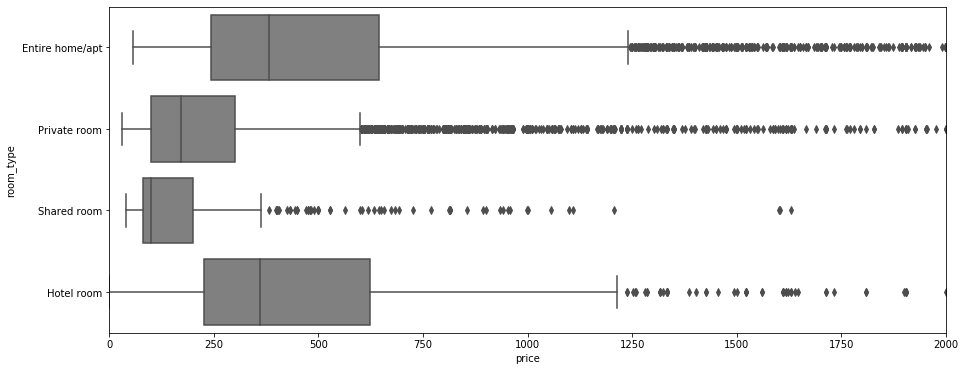

```python
plt.figure(figsize = (15,6))
sns.boxplot(x = 'price', y = 'room_type', data = df_graph, color = 'grey')
plt.xlim(0,2000);
```

I'm going to list my entire home in Beyoglu in european side so I can make above the average price in Istanbul from my apartment

## Question 4: Can I predict the listing prices?

```
r2 Score: 0.60, MSE : 0.28
```

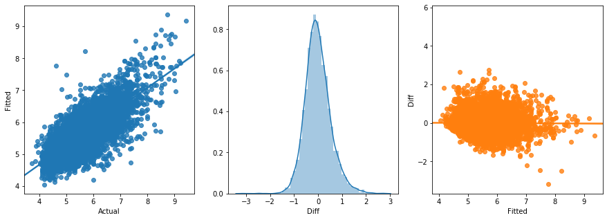

|  | Actual | Fitted | Diff |
| --- | --- | --- | --- |
| 0 | 5.655992 | 5.778031 | -0.122039 |
| 1 | 4.718499 | 5.724648 | -1.006149 |
| 2 | 4.110874 | 4.751279 | -0.640405 |
| 3 | 4.969813 | 5.810310 | -0.840497 |
| 4 | 5.624018 | 6.013915 | -0.389897 |
| ... | ... | ... | ... |
| 6621 | 4.499810 | 4.475555 | 0.024255 |
| 6622 | 7.384610 | 7.222631 | 0.161979 |
| 6623 | 5.147494 | 5.379427 | -0.231932 |
| 6624 | 4.418841 | 5.290440 | -0.871599 |
| 6625 | 6.386879 | 6.209041 | 0.177838 |

6626 rows × 3 columns

```python
actual_vs_predicted(y_test,pred)
```